# (Ford-GoBike Presentation )

## Investigation Overview

The goal of this presentation is to show how the age, gender and user_type affect duration of trips in minutes and distance in km

## Dataset Overview

There are 183412 triprides in the dataset with 16 features (duration_sec, start_time, end_time , start_station_id, start_station_name, start_station_latitude, start_station_id, start_station_longitude, end_station_name, end_station_latitude, end_station_longitude, bike_id, user_type, member_birth_year, member_gender, bike_share_for_all_trip ). Most variables are numeric in nature, but the variables start_time and end_time are date & time and the variables start_station_name, end_station_name, user_type, member_gender are object type and finaly the bike share for all trip feature is of type boolean

```python
# import all packages and set plots to be embedded inline
import numpy as np
import pandas as pd
import matplotlib.pyplot as plt
import seaborn as sb

%matplotlib inline

# suppress warnings from final output
import warnings
warnings.simplefilter("ignore")
```

```python
# load in the dataset into a pandas dataframe
df = pd.read_csv('fordgobike-tripdata.csv')

df['start_time'] = pd.to_datetime(df.start_time)
df['end_time'] = pd.to_datetime(df.end_time)
df['Start_Month']=df['start_time'].dt.month
df['duration_min']=df['duration_sec']/60
df['Day_Name']=df['start_time'].dt.day_name()

df['Age']=2021-df['member_birth_year']
Age_Group_Labels=['Youth','Adults','Seniors']

Age_Group_Limits=[15,24,63,64]

df['Age_Group']=pd.cut(df['Age'],bins=Age_Group_Limits,labels=Age_Group_Labels,right=False)

Duration_conditions=[(df['duration_min']<5),
                     (df['duration_min']>=5) & (df['duration_min']<10),
           (df['duration_min']>=10) &(df['duration_min']<30),
           (df['duration_min']>=30) &(df['duration_min']<60),
           (df['duration_min']>=60)&(df['duration_min']<24),
           (df['duration_min']>=24)]

Duration_labels= ['Less Than 5 min','5 min to 10 min','10 min to 30 min','30+ min','1 hour or more','1 day or more']
df['Duration_Labels']=np.select(Duration_conditions,Duration_labels)
```

```python
def Distance_Haversine(lon_start, lat_start, lat_end, lon_end):

    lon_start, lat_start, lat_end, lon_end = map(np.radians, [lon_start, lat_start, lat_end, lon_end])

    lon_diff = np.absolute(lon_end - lon_start)
    lat_diff = np.absolute(lat_end - lat_start)


    dist = 2 * np.arcsin(np.sqrt(np.sin(lat_diff/2.0)**2 + np.cos(lat_start) * np.cos(lat_end) * np.sin(lon_diff/2.0)**2 ))
    dist_km = (6367 * dist)
    return dist_km

df['Distance'] =  Distance_Haversine(df['start_station_longitude'],df['start_station_latitude'],df['end_station_latitude'],df['end_station_longitude'])
```

## Duration

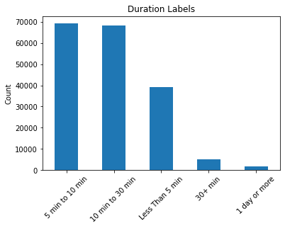

```python
duration_label_count=df['Duration_Labels'].value_counts()

plt.ylabel('Count')

duration_label_count.plot.bar();
plt.xticks(rotation=45);

plt.title('Duration Labels');
```

# Distance

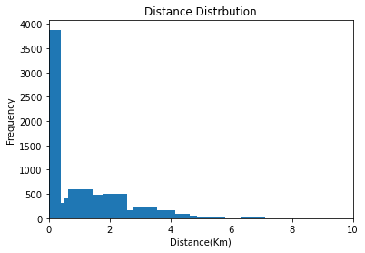

```python
distance_count=df.Distance.value_counts();

plt.bar(distance_count.index,distance_count.values);
plt.ylabel('Frequency');

plt.xlabel('Distance(Km)');

plt.xlim(0,10); # this limit best express data found during exploration

plt.title('Distance Distrbution')
```

# Age

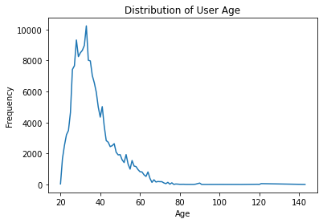

```python
df['Age'].value_counts().sort_index().plot.line()
plt.xlabel('Age')
plt.ylabel('Frequency')
plt.title('Distribution of User Age')
plt.show()
```

# Gender & User Type Distrbution

Most of the gender category are male

Most of user type are subscribers

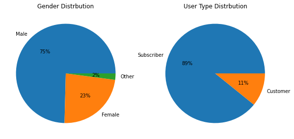

```python
genderr=df['member_gender'].value_counts()
user_typee = df["user_type"].value_counts()

plt.figure(figsize=(15,5))
plt.subplot(1,2,1);
genderr.plot.pie(figsize=(10,10), autopct='%1.0f%%');
plt.title('Gender Distrbution')
plt.ylabel('')
plt.subplot(1,2,2);
user_typee.plot.pie(figsize=(10,10), autopct='%1.0f%%');
plt.title('User Type Distrbution')
plt.ylabel('')
plt.show()
```

# Age_Group Count

Mof of the dataset age of the users are adults

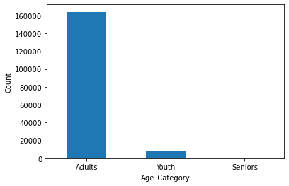

```python
df.Age_Group.value_counts().plot.bar();
plt.xticks(rotation=360);
plt.xlabel('Age_Category');
plt.ylabel('Count');
```

## Duration Age and Distance Relation

Age from 25 to 50 tend to have more trip duration and surprisingly the lower the distance the more the duration

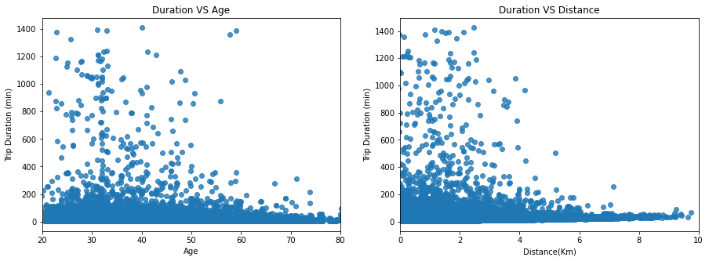

```python
plt.figure(figsize=(15,5))
plt.subplot(1,2,1);

sb.regplot(data = df, x = 'Age', y = 'duration_min', truncate=False, x_jitter=0.3);
plt.xlabel('Age')
plt.xlim(20, 80)
plt.ylabel('Trip Duration (min)')
plt.title('Duration VS Age')


plt.subplot(1,2,2);


sb.regplot(data = df, x = 'Distance', y = 'duration_min', truncate=False, x_jitter=0.3,fit_reg=False);
plt.xlabel('Distance(Km)')
plt.ylabel('Trip Duration (min)')
plt.title('Duration VS Distance');
plt.xlim(0,10);
```

## Distance VS Gender Regarding User Type and Age Group

Male and Customers tend to cover more distance than other user type and gender

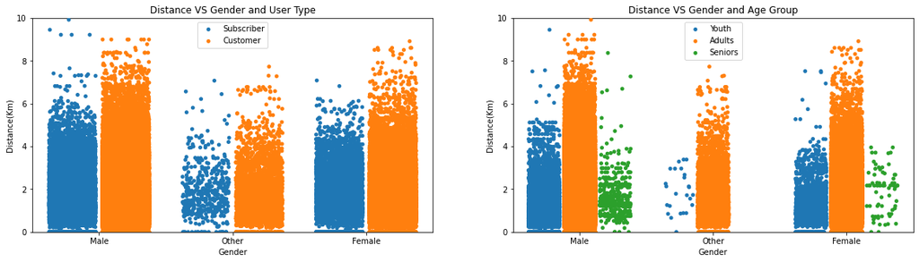

```python
plt.figure(figsize=(20,5))
plt.subplot(1,2,1);
sb.stripplot(data=df, x='member_gender',y='Distance',hue='user_type',jitter=0.35,dodge=True)
plt.xlabel('Gender')
plt.ylabel('Distance(Km)');

plt.ylim(0,10)

plt.legend(['Subscriber','Customer']);

plt.title('Distance VS Gender and User Type');
plt.subplot(1,2,2);

sb.stripplot(data=df, x='member_gender',y='Distance',hue='Age_Group',jitter=0.35,dodge=True)
plt.xlabel('Gender')
plt.ylabel('Distance(Km)');
plt.legend(['Youth','Adults','Seniors']);

plt.ylim(0,10)

plt.title('Distance VS Gender and Age Group');
```

## Duration VS Distance Regarding User Type and Age Group

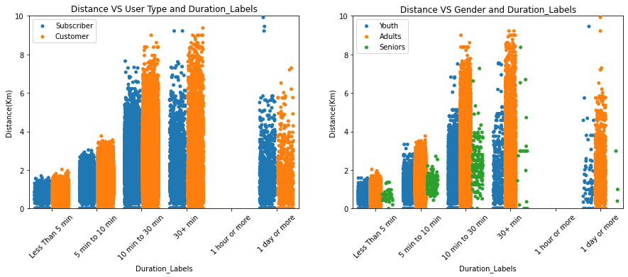

```python
plt.figure(figsize=(15,5))
plt.subplot(1,2,1);

sb.stripplot(data=df, x='Duration_Labels',y='Distance',hue='user_type',jitter=0.35,dodge=True,order=['Less Than 5 min','5 min to 10 min','10 min to 30 min','30+ min','1 hour or more','1 day or more'])
plt.xlabel('Duration_Labels')
plt.ylabel('Distance(Km)');
plt.legend(['Subscriber','Customer']);
plt.xticks(rotation=45);

plt.ylim(0,10)

plt.title('Distance VS User Type and Duration_Labels');



plt.subplot(1,2,2);

sb.stripplot(data=df, x='Duration_Labels',y='Distance',hue='Age_Group',jitter=0.35,dodge=True,order=['Less Than 5 min','5 min to 10 min','10 min to 30 min','30+ min','1 hour or more','1 day or more'])
plt.xlabel('Duration_Labels')
plt.ylabel('Distance(Km)');
plt.legend(['Youth','Adults','Seniors']);
plt.xticks(rotation=45);

plt.ylim(0,10)

plt.title('Distance VS Gender and Duration_Labels');
```

```python
!jupyter nbconvert ford_slide_deck.ipynb --to slides --post serve  --no-input --no-prompt
```